# Homework 8

Anusha Ramamurthy

March 24, 2016

Question 1: Problem Set A

Q1.1. Assume that n = 400 observations are independently drawn from a normal distribution with unknown population mean μ and unknown population variance σ2. The resulting sample, x’, is used to test H0 : μ ≤ 0 versus H1 : μ > 0 at significance level α = 0.05.

1. What test should be used in this situation? If we observe x’ that results in x’ = 3.194887 and s2 = 104.0118, then what is the value of the test statistic?
- Answer: Since the sample size is large we can use either z-test or t-test. however since s2 is given we use the t-test

```r
t = (3.194887-0)/sqrt(104.0118/400)
t
```

```
## [1] 6.265333
```

2. If we observe x’ that results in a test statistic value of 1.253067, then which of the following R expressions best approximates the significance probability?
1. 2*pnorm(1.253067)
2. 2*pnorm(-1.253067)
3. 1-pnorm(1.253067)
4. 1-pt(1.253067,df=399)
5. pt(1.253067,df=399)
- Answer: iii. 1-pnorm(1.253067) and iv. 1-pt(1.253067,df=399)

```r
1-pnorm(1.253067)
```

```
## [1] 0.1050907
```

```r
1-pt(1.253067,df=399)
```

```
## [1] 0.1054576
```

3. True of False: if we observe x’ that results in a significance probability of p = 0.03044555, then we should reject the null hypothesis.
- Answer: Significance level α = 0.05 , since p < α , the statement is true.

Q1.2. A device counts the number of ions that arrive in a given time interval, unless too many arrive. An experiment that relies on this device produces the following counts, where Big means that the count exceeded 255.

251 238 249 Big 243 248 229 Big 235 244 254 251 252 244 230 222 224 246 Big 239

Use these data to construct a confidence interval for the population median number of ions with a confidence coefficient of approximately 0.95.

```r
#we have 3 numbers larger than 255
#n-3 = 20-3 = 17
#qbinom(0.95/17,20,0.5)
k = qbinom(0.95/17,20,0.5)
k
```

```
## [1] 6
```

```r
x = c (251,238,249,256,243,248,229,256,235,244,254,251,252,244,230,222,224,246,256,239)
pbinom(5,20,0.5)
```

```
## [1] 0.02069473
```

```r
1-2*pbinom(5,20,0.5)
```

```
## [1] 0.9586105
```

```r
y = sort(x)
y
```

```
##  [1] 222 224 229 230 235 238 239 243 244 244 246 248 249 251 251 252 254
## [18] 256 256 256
```

```r
cf = c(y[k],y[20-k])
cf
```

```
## [1] 238 251
```

- confidence intreval = (238,251)

Problem Set B

Q2.1. The following exercises elaborate on the case study explicated in Section 10.4. The sample, x’, is the final column in Table 10.2.

1. Refer to Figure 10.1. The tails in the normal probability plot do not appear to be consistent with an assumption of normality, but the lack of linearity might be due to sampling variation. To investigate whether or not this is the case, please do the following:
1. Use rnorm to generate four samples from a normal distribution, each with n = 19 observations.

```r
r1 = rnorm(19)
r2 = rnorm(19)
r3 = rnorm(19)
r4 = rnorm(19)
```

2. Construct a normal probability plot for each simulated sample. Compare these plots to the normal probability plot of x’ in Figure 10.1.

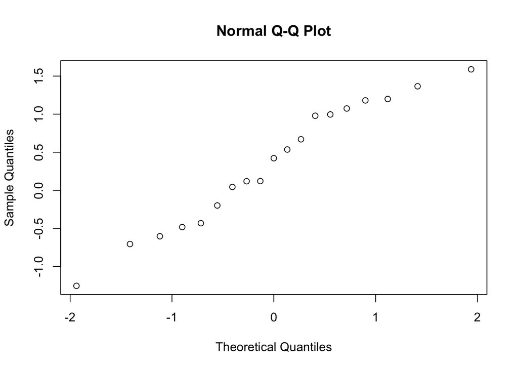

```r
qqnorm(r1)
```

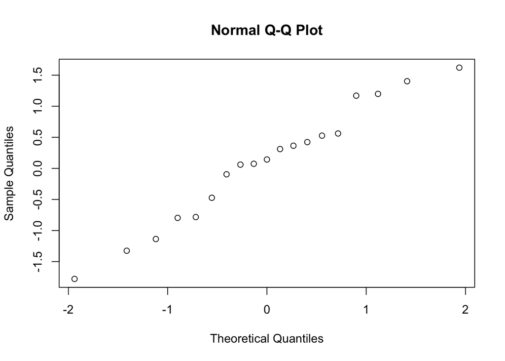

```r
qqnorm(r2)
```

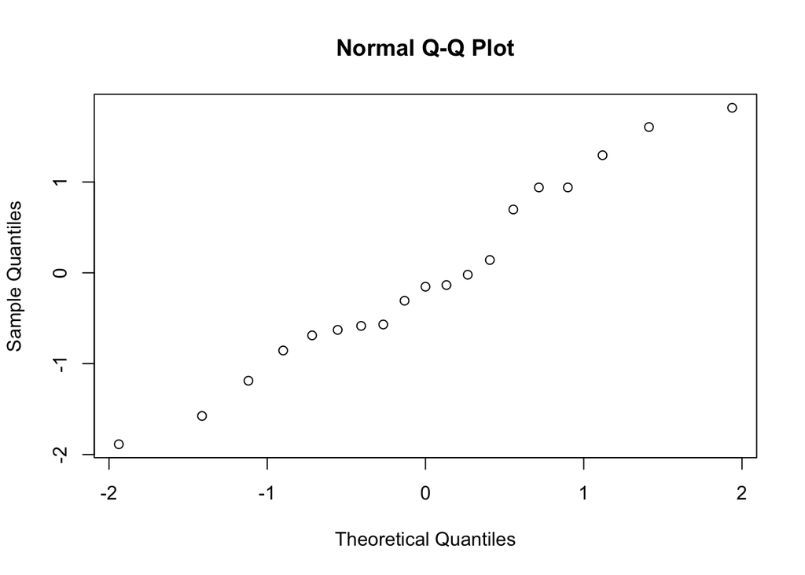

```r
qqnorm(r3)
```

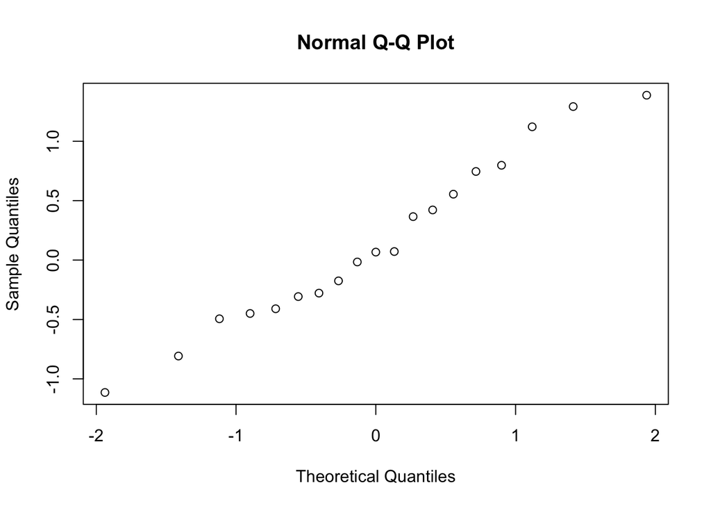

```r
qqnorm(r4)
```

```r
get_iqr = function (s){
q <- as.vector(quantile(s,probs=c(.25,.75)))
iqr <- q[2]-q[1]
return (iqr)
}

CPA_log_vals = c(1.1402, -1.8658, 0.8520, -1.8251, 0.8530, -0.0589, -1.6554,
-1.7599, -1.4330, -1.3853, 2.9794, 2.4919, 2.1601, 2.2670,
-0.5479, -0.7164, 0.6462, -0.8365, 1.1997)

iqr_sd_cpa = get_iqr(CPA_log_vals)/sd(CPA_log_vals)
iqr_sd_cpa
```

```
## [1] 1.590833
```

```r
iqr_sd1 = get_iqr(r1)/sd(r1)
iqr_sd1
```

```
## [1] 1.664012
```

```r
iqr_sd2 = get_iqr(r2)/sd(r2)
iqr_sd2
```

```
## [1] 1.243053
```

```r
iqr_sd3 = get_iqr(r3)/sd(r3)
iqr_sd3
```

```
## [1] 1.414718
```

```r
iqr_sd4 = get_iqr(r4)/sd(r4)
iqr_sd4
```

```
## [1] 1.427935
```

4. Reviewing the available evidence, are you comfortable assuming that x’ was drawn from a normal distribution? Do four simulated samples provide enough information to answer the preceding question?
- Answer: A sample size of 19 is too small to make a broad conclusion. So we cant convinsingly say that x’ is drawn from a normal distribution.

Q2.2. Assuming that X1, . . . ,X19 ∼ Normal(μ, σ2), use Student’s 1-sample test to test H0 : μ ≤ 0 versus H1 : μ > 0 with a significance level of α = 0.05. Construct a two-sided confidence interval for μ with a confidence coefficient of 1 − α = 0.90. Compare the results of these analyses to the results obtained in Section 10.4.

```r
t = mean(CPA_log_vals) / (sd(CPA_log_vals)/sqrt(19))
1-pt(t,df=18)
```

```
## [1] 0.3635348
```

- Answer: The p value 0.3635348 is much higher than the significance level of α = 0.05. So we dont reject the idea that the µ is less than equal to zero.

```r
cf = c((mean(CPA_log_vals) - (qt(0.95,df=18) * (sd(CPA_log_vals)/sqrt(19)))),(mean(CPA_log_vals) + (qt(0.95,df=18) * (sd(CPA_log_vals)/sqrt(19)))))
cf
```

```
## [1] -0.5131008  0.7768166
```

- Case study 10.4 identifies the same confidence intervals but uses a different test.

Q2.3. Assuming only that X1, . . . ,X19 are continuous random variables with population median θ, use the sign test to test H0 : θ ≤ 0 versus H1 : θ > 0 with a significance level of α ≈ 0.05. Construct a two sided confidence interval for θ with a confidence coefficient of 1 − α ≈ 0.90. Compare the results of these analyses to the results obtained in Section 10.4.

```r
positive = sum(CPA_log_vals > 0)
k = qbinom(0.90/positive,19,0.5)
k
```

```
## [1] 7
```

```r
1 - pbinom(positive, 19, 0.5)
```

```
## [1] 0.5
```

```r
y = sort(CPA_log_vals)
y
```

```
##  [1] -1.8658 -1.8251 -1.7599 -1.6554 -1.4330 -1.3853 -0.8365 -0.7164
##  [9] -0.5479 -0.0589  0.6462  0.8520  0.8530  1.1402  1.1997  2.1601
## [17]  2.2670  2.4919  2.9794
```

```r
y_rev = sort(CPA_log_vals,decreasing = TRUE)
y_rev
```

```
##  [1]  2.9794  2.4919  2.2670  2.1601  1.1997  1.1402  0.8530  0.8520
##  [9]  0.6462 -0.0589 -0.5479 -0.7164 -0.8365 -1.3853 -1.4330 -1.6554
## [17] -1.7599 -1.8251 -1.8658
```

```r
cf = c(y[k-1],y_rev[k-1])
cf
```

```
## [1] -1.3853  1.1402
```

Question: Set D

The ancient Greeks greatly admired rectangles with a height-to-width ratio of 1 : 1 + √5 / 2 = 0.618034. They called this number the “golden ratio” and used it repeatedly in their art and architecture, e.g., in building the Parthenon. Furthermore, golden rectangles are often found in the art of later western cultures. A cultural anthropologist wondered if the Shoshoni, a native American civilization, also used golden rectangles. The following measurements, which appear as Data Set 150 in A Handbook of Small Data Sets, are height-to width ratios of beaded rectangles used by the Shoshoni in decorating various leather goods:

0.693 0.662 0.690 0.606 0.570 0.749 0.672 0.628 0.609 0.844 0.654 0.615 0.668 0.601 0.576 0.670 0.606 0.611 0.553 0.933

We will analyze the Shoshoni rectangles as a 1-sample location problem.

Q3.1. There are two natural scales that we might use in analyzing these data. One possibility is to analyze the ratios themselves; the other is to analyze the (natural) logarithms of the ratios. For which of these possibilities would an assumption of normality seem more plausible? Please justify your answer.

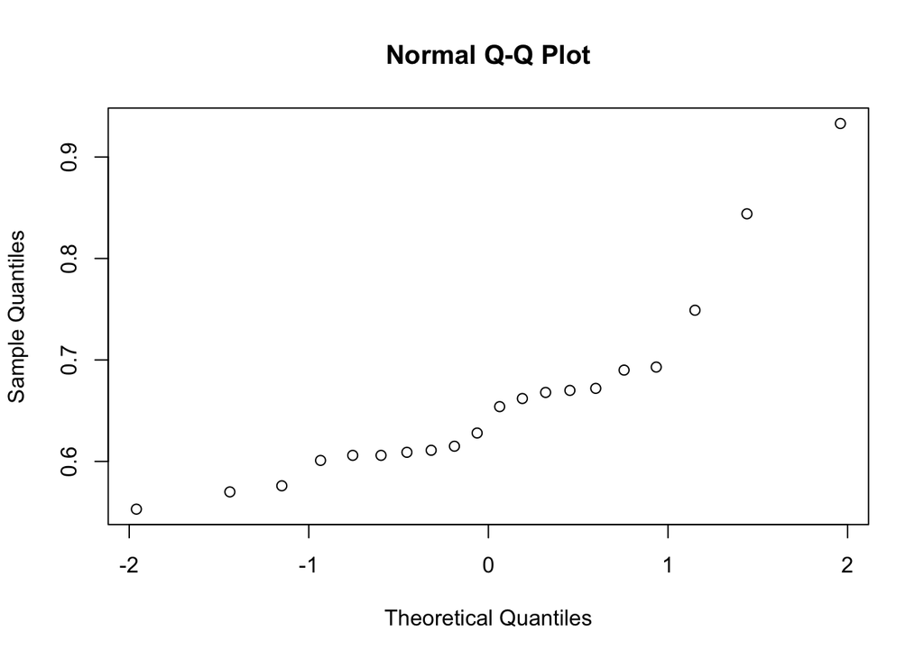

```r
x = c( 0.693, 0.662, 0.690, 0.606, 0.570,
0.749, 0.672, 0.628, 0.609, 0.844,
0.654, 0.615, 0.668, 0.601, 0.576,
0.670, 0.606, 0.611, 0.553, 0.933)
qqnorm(x)
```

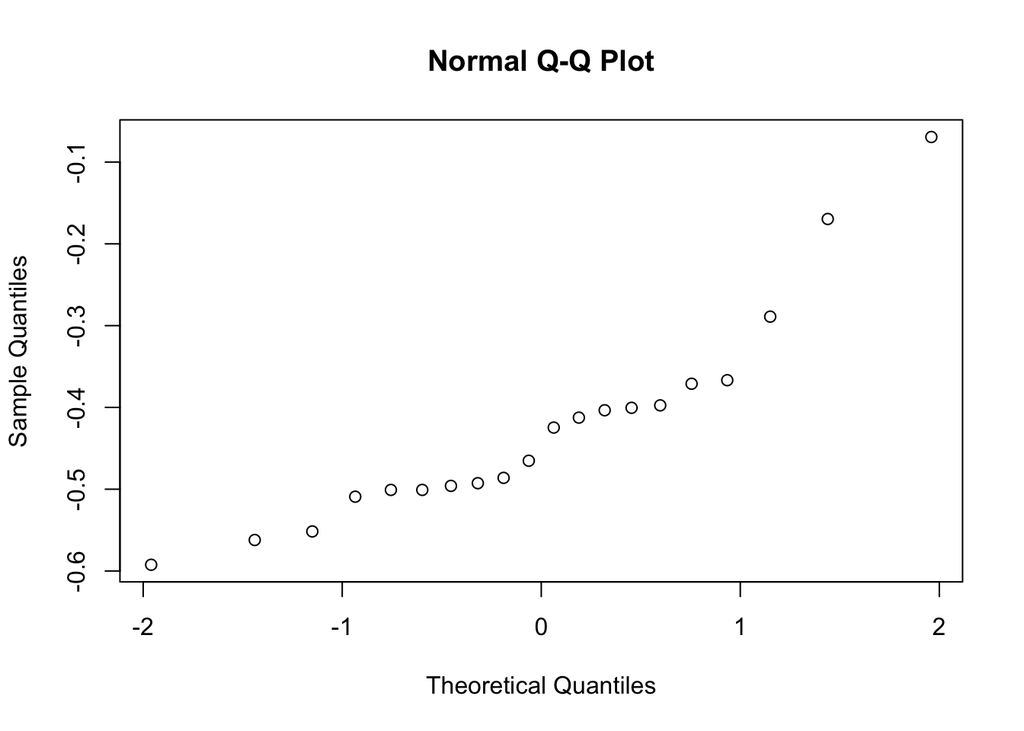

```r
qqnorm(log(x))
```

Q3.2. Choose the possibility (ratios or logarithms of ratios) for which an assumption of normality seems more plausible. Formulate suitable null and alternative hypotheses for testing the possibility that the Shoshoni were using golden rectangles. Using Student’s 1-sample t-test, compute a significance probability for testing these hypotheses. Would you reject or accept the null hypothesis using a significance level of 0.05?

- Answer: We can take H0 : µ = (2/1+sqrt(5)), ie the Shoshini tribe used the golden rectangles. H1 : µ <> (2/1+sqrt(5))

```r
m = 2/(1+sqrt(5))
t = (mean(x) - m ) / (sd(x) / sqrt(20))
2 * (1 - pt(abs(t), df = 19))
```

```
## [1] 0.0541156
```

```r
m = 2/(1+sqrt(5))
t = (mean(log(x)) - log(m) ) / (sd(log(x)) / sqrt(20))
2 * (1 - pt(abs(t), df = 19))
```

```
## [1] 0.05771059
```

- The p-value for both the cases is only slightly higher than 0.05, so accept the null hypothesis

Q3.3. Suppose that we are unwilling to assume that either the ratios or the log-ratios were drawn from a normal distribution. Use the sign test to construct a 0.90-level confidence interval for the population median of the ratios.

```r
pve = sum(x > 0.618034)
k = qbinom(0.90/pve, 20 , 0.5)
k
```

```
## [1] 7
```

```r
#pbinom(k-1 ,20,0.5)
1-2*pbinom(k-1,20,0.5)
```

```
## [1] 0.8846817
```

```r
y = sort(x)
y
```

```
##  [1] 0.553 0.570 0.576 0.601 0.606 0.606 0.609 0.611 0.615 0.628 0.654
## [12] 0.662 0.668 0.670 0.672 0.690 0.693 0.749 0.844 0.933
```

```r
y_rev = sort(x,decreasing = TRUE)
y_rev
```

```
##  [1] 0.933 0.844 0.749 0.693 0.690 0.672 0.670 0.668 0.662 0.654 0.628
## [12] 0.615 0.611 0.609 0.606 0.606 0.601 0.576 0.570 0.553
```

```r
cf = c(y[k-1],y_rev[k-1])
cf
```

```
## [1] 0.606 0.672
```

Q4. A researcher wanted to see if live reggae music improved students’ math test scores. He selected a sample of 61 students from his university and gave them a math test. The students then studied for two and a half hours while an acoustic reggae band played quietly. The students then took another math test of the same difficulty. The researcher’s variable was the change in test score for each student - a positive change meant the student did better after listening to reggae, while a negative change meant a student did worse. He found that the changes had an approximately normal distribution with mean 6.5 and standard deviation 12. a. Assuming the sample is random, test the hypothesis that the population average is positive.

- Answer: H0: µ => 0, H1: µ < 0

```r
z = (6.5 - 0) / (12/sqrt(61))
pnorm(z)
```

```
## [1] 0.9999883
```